# Logistic regression

```r
date()
```

```
## [1] "Tue Nov 22 00:04:41 2022"
```

In this report I examine the relationship between student alcohol consumption and student achievement in secondary education of two Portuguese schools. For the use of this report I combined two datasets including student grades (Mathematics and Portuguese language), demographic, social and school related features. More information about the data: https://archive.ics.uci.edu/ml/datasets/Student+Performance  
In the combined datatable “alc” there is 35 variables (listed below). The variable “alc_use” is a simply calculated as the average of work day and weekend alcohol consumption (“walc” and “Dalc”, respectively). The variable “high_use” is a binary variable that indicates whether the respondent’s alcohol consumption is high or not (TRUE/FALSE). Alcohol consumption is considered high (“high_use” = TRUE) if “alc_use” is greater than 2. The purpose of this analysis is to study the relationships between high/low alcohol consumption and academic achievement.

```r
alc <- read.table("data/alc.csv", sep=",", header=TRUE)

colnames(alc)
```

```
##  [1] "school"     "sex"        "age"        "address"    "famsize"
##  [6] "Pstatus"    "Medu"       "Fedu"       "Mjob"       "Fjob"
## [11] "reason"     "guardian"   "traveltime" "studytime"  "schoolsup"
## [16] "famsup"     "activities" "nursery"    "higher"     "internet"
## [21] "romantic"   "famrel"     "freetime"   "goout"      "Dalc"
## [26] "Walc"       "health"     "failures"   "paid"       "absences"
## [31] "G1"         "G2"         "G3"         "alc_use"    "high_use"
```

Let’s examine the relationship between high/low alcohol use and gender, number of school absences, number of past class failures, and final grade. My personal hypothesis is that high alcohol use is more common with male students, and that the final grades are lower and the number of past class failures and school absences is greater with those student using more alcohol. Let’s draw up a few graphs to support the hypothesis.

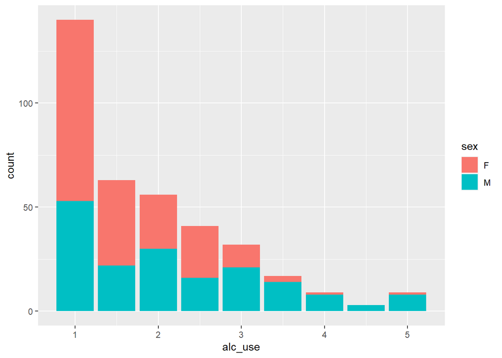

```r
library(ggplot2)

# initialize a plot of alcohol use
g1 <- ggplot(data = alc, aes(x = alc_use, fill=sex))

# define the plot as a bar plot and draw it
g1 + geom_bar()
```

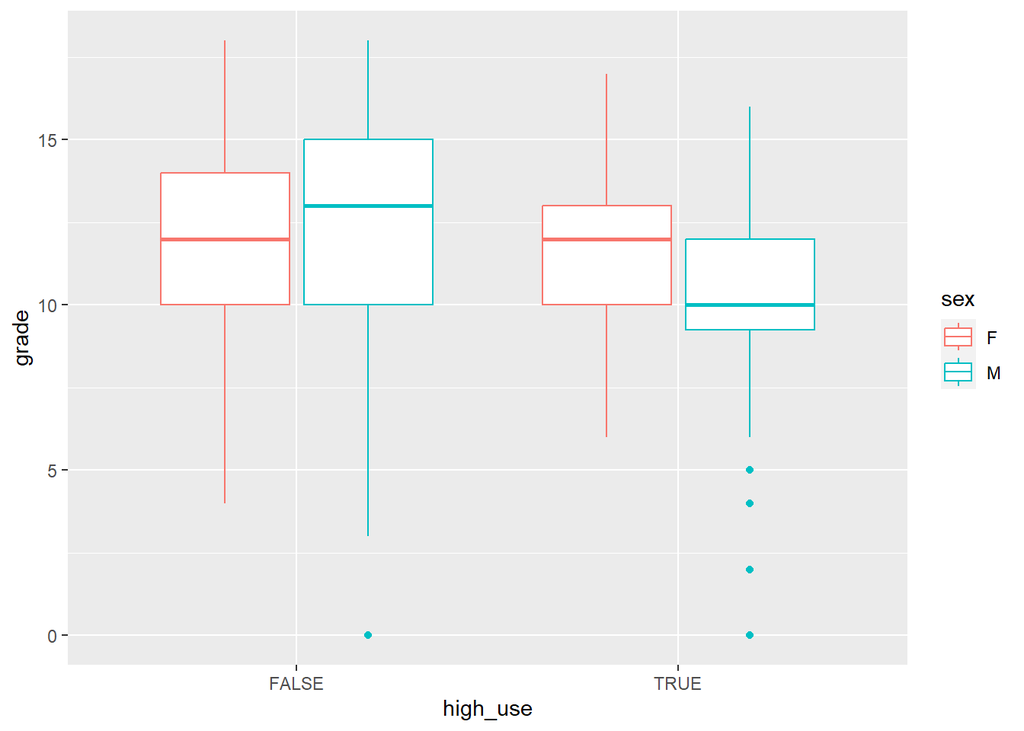

```r
# initialize a plot of high_use and G3
g2 <- ggplot(alc, aes(x = high_use, y = G3, col = sex))

# define the plot as a boxplot and draw it
g2 + geom_boxplot() + ylab("grade")
```

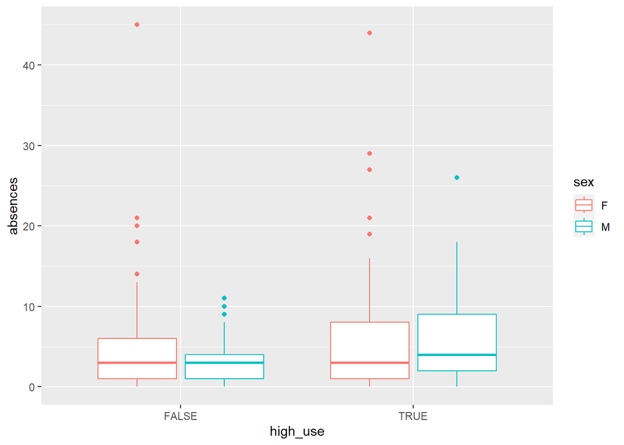

```r
# initialize a plot of high_use and absences
g3 <- ggplot(alc, aes(x = high_use, y = absences, col = sex))

# define the plot as a box plot and draw it
g3 + geom_boxplot() + ylab("absences")
```

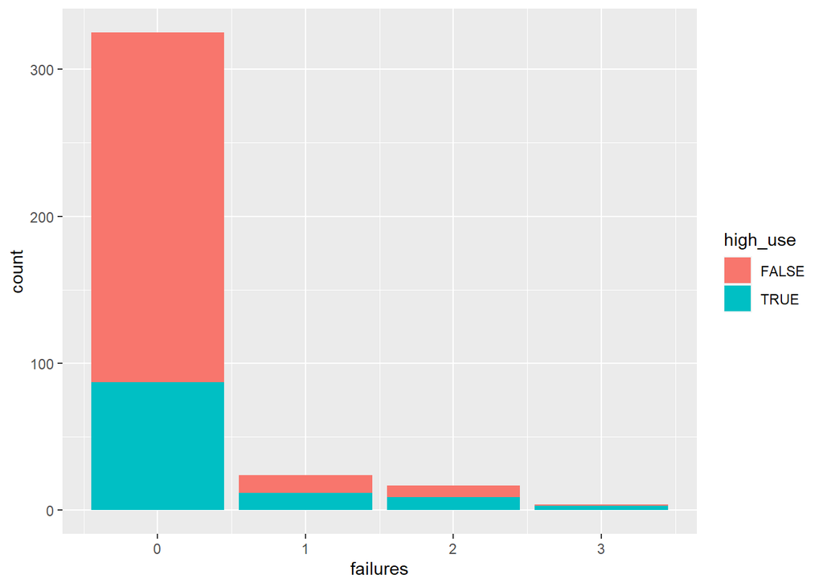

```r
# initialize a plot of high_use and failures
g4 <- ggplot(data = alc, aes(x = failures, fill=high_use))

# define the plot as a bar plot and draw it
g4 + geom_bar()
```

The first bar graph shows that the higher the alcohol consumption (ranging from 1 to 5) the higher the proportion of students are male. In the second and third plots we see that especially with male students the average grade is lower and the number of absences is higher in the high alcohol use group. For female students the results seems to be similar, but not as clear. The fourth graph describes the past failures in high/low alcohol consumption groups. The higher the number of past failures, the higher the proportion of students in high alcohol consumption group.  
Summary statistics can also be viewed in numerical format. Let’s prepare a table, from which we can see the average grade, the number of absences and the past failures in the high and low alcohol consumption groups by gender.

```r
# access the tidyverse libraries dplyr and ggplot2
library(dplyr); library(ggplot2)
# produce summary statistics by group
alc %>% group_by(sex, high_use) %>% summarise(count = n(), mean_grade=mean(G3), mean_absences=mean(absences), mean_failures=mean(failures))
```

[output not shown]

```
## # A tibble: 4 × 6
## # Groups:   sex [2]
##   sex   high_use count mean_grade mean_absences mean_failures
##   <chr> <lgl>    <int>      <dbl>         <dbl>         <dbl>
## 1 F     FALSE      154       11.4          4.25         0.104
## 2 F     TRUE        41       11.8          6.85         0.293
## 3 M     FALSE      105       12.3          2.91         0.143
## 4 M     TRUE        70       10.3          6.1          0.386
```

The table verifies that the average number of absences and average number of past failures is greater in high alcohol consumption groups for both genders. In male students’ high alcohol consumption group the mean grade is clearly lower in than low alcohol consumption group. However, in female students’ high alcohol consumption group the mean grade is actually slightly higher than in low alcohol consumption group.

**Logistic regression model**  
Let’s explore statistically using logistic regression the relationship between gender, grade, absences, and failures, and the binary high/low alcohol consumption variable as the target variable. I’m going to add the variables to the modle one by one, starting with failures.

```r
# find the model with glm()
m <- glm(high_use ~ failures, data = alc, family = "binomial")

# print out a summary of the model
summary(m)
```

```
##
## Call:
## glm(formula = high_use ~ failures, family = "binomial", data = alc)
##
## Deviance Residuals:
##     Min       1Q   Median       3Q      Max
## -1.6367  -0.7943  -0.7943   1.3143   1.6171
##
## Coefficients:
##             Estimate Std. Error z value Pr(>|z|)
## (Intercept)  -0.9920     0.1234  -8.040 8.99e-16 ***
## failures      0.6759     0.1973   3.425 0.000615 ***
## ---
## Signif. codes:  0 '***' 0.001 '**' 0.01 '*' 0.05 '.' 0.1 ' ' 1
##
## (Dispersion parameter for binomial family taken to be 1)
##
##     Null deviance: 452.04  on 369  degrees of freedom
## Residual deviance: 439.75  on 368  degrees of freedom
## AIC: 443.75
##
## Number of Fisher Scoring iterations: 4
```

```r
# print out the coefficients of the model
coef(m)
```

```
## (Intercept)    failures
##  -0.9920231   0.6758788
```

The past failures are significantly associated with the probability of student belonging to the high alcohol consumption group (p = 0,000615). AIC of the model is 443,75. Let’s add absencess to the model.

```r
# find the model with glm()
m <- glm(high_use ~ failures + absences, data = alc, family = "binomial")

# print out a summary of the model
summary(m)
```

```
##
## Call:
## glm(formula = high_use ~ failures + absences, family = "binomial",
##     data = alc)
##
## Deviance Residuals:
##     Min       1Q   Median       3Q      Max
## -2.2281  -0.7747  -0.6937   1.2043   1.7939
##
## Coefficients:
##             Estimate Std. Error z value Pr(>|z|)
## (Intercept) -1.38590    0.16717  -8.290  < 2e-16 ***
## failures     0.64059    0.20050   3.195 0.001398 **
## absences     0.08402    0.02306   3.644 0.000269 ***
## ---
## Signif. codes:  0 '***' 0.001 '**' 0.01 '*' 0.05 '.' 0.1 ' ' 1
##
## (Dispersion parameter for binomial family taken to be 1)
##
##     Null deviance: 452.04  on 369  degrees of freedom
## Residual deviance: 423.97  on 367  degrees of freedom
## AIC: 429.97
##
## Number of Fisher Scoring iterations: 4
```

```r
# print out the coefficients of the model
coef(m)
```

```
## (Intercept)    failures    absences
## -1.38589606  0.64059042  0.08401658
```

Both failures and absences are statistically significant. The AIC value is smaller than in the first model, which means that this model is better than the first one. Let’s add gender as a third independent variable.

```r
# find the model with glm()
m <- glm(high_use ~ failures + absences + sex, data = alc, family = "binomial")

# print out a summary of the model
summary(m)
```

```
##
## Call:
## glm(formula = high_use ~ failures + absences + sex, family = "binomial",
##     data = alc)
##
## Deviance Residuals:
##     Min       1Q   Median       3Q      Max
## -2.1550  -0.8430  -0.5889   1.0328   2.0374
##
## Coefficients:
##             Estimate Std. Error z value Pr(>|z|)
## (Intercept) -1.94150    0.23129  -8.394  < 2e-16 ***
## failures     0.59759    0.20698   2.887  0.00389 **
## absences     0.09245    0.02323   3.979 6.91e-05 ***
## sexM         0.99731    0.24725   4.034 5.49e-05 ***
## ---
## Signif. codes:  0 '***' 0.001 '**' 0.01 '*' 0.05 '.' 0.1 ' ' 1
##
## (Dispersion parameter for binomial family taken to be 1)
##
##     Null deviance: 452.04  on 369  degrees of freedom
## Residual deviance: 406.99  on 366  degrees of freedom
## AIC: 414.99
##
## Number of Fisher Scoring iterations: 4
```

```r
# print out the coefficients of the model
coef(m)
```

```
## (Intercept)    failures    absences        sexM
## -1.94149584  0.59759293  0.09245138  0.99731318
```

All three independent variables are statistically significantly associated with the probability of student belonging to the high alcohol consumption group. The AIC value again smaller, so this model is again better at predicting if student belongs to the high alcohol consumption group than the two earlier models. Let’s add the fourth variable, final grade, to the model.

```r
# find the model with glm()
m <- glm(high_use ~ failures + absences + sex + G3, data = alc, family = "binomial")

# print out a summary of the model
summary(m)
```

```
##
## Call:
## glm(formula = high_use ~ failures + absences + sex + G3, family = "binomial",
##     data = alc)
##
## Deviance Residuals:
##     Min       1Q   Median       3Q      Max
## -2.1561  -0.8429  -0.5872   1.0033   2.1393
##
## Coefficients:
##             Estimate Std. Error z value Pr(>|z|)
## (Intercept) -1.38733    0.51617  -2.688  0.00719 **
## failures     0.50382    0.22018   2.288  0.02213 *
## absences     0.09058    0.02322   3.901 9.56e-05 ***
## sexM         1.00870    0.24798   4.068 4.75e-05 ***
## G3          -0.04671    0.03948  -1.183  0.23671
## ---
## Signif. codes:  0 '***' 0.001 '**' 0.01 '*' 0.05 '.' 0.1 ' ' 1
##
## (Dispersion parameter for binomial family taken to be 1)
##
##     Null deviance: 452.04  on 369  degrees of freedom
## Residual deviance: 405.59  on 365  degrees of freedom
## AIC: 415.59
##
## Number of Fisher Scoring iterations: 4
```

```r
# print out the coefficients of the model
coef(m)
```

```
## (Intercept)    failures    absences        sexM          G3
## -1.38732604  0.50382370  0.09057516  1.00870144 -0.04670941
```

Now the past failures, absences, and gender are significantly associated with the probability of student belonging to the high alcohol consumption group but the final grade, however, is not (p=0,24). The AIC value is also a little bit higher in this last model, which indicates that the final grade might not be a good predictor of students’ high alcohol consumption. So let’s remove that from the model and computate the odds ratios and confidence intervals for the model that includes failures, absences and gender.

```r
# find the model with glm()
m <- glm(high_use ~ failures + absences + sex, data = alc, family = "binomial")

# print out a summary of the model
summary(m)
```

```
##
## Call:
## glm(formula = high_use ~ failures + absences + sex, family = "binomial",
##     data = alc)
##
## Deviance Residuals:
##     Min       1Q   Median       3Q      Max
## -2.1550  -0.8430  -0.5889   1.0328   2.0374
##
## Coefficients:
##             Estimate Std. Error z value Pr(>|z|)
## (Intercept) -1.94150    0.23129  -8.394  < 2e-16 ***
## failures     0.59759    0.20698   2.887  0.00389 **
## absences     0.09245    0.02323   3.979 6.91e-05 ***
## sexM         0.99731    0.24725   4.034 5.49e-05 ***
## ---
## Signif. codes:  0 '***' 0.001 '**' 0.01 '*' 0.05 '.' 0.1 ' ' 1
##
## (Dispersion parameter for binomial family taken to be 1)
##
##     Null deviance: 452.04  on 369  degrees of freedom
## Residual deviance: 406.99  on 366  degrees of freedom
## AIC: 414.99
##
## Number of Fisher Scoring iterations: 4
```

```r
# print out the coefficients of the model
coef(m)
```

```
## (Intercept)    failures    absences        sexM
## -1.94149584  0.59759293  0.09245138  0.99731318
```

```r
# compute odds ratios (OR)
OR <- coef(m) %>% exp

# compute confidence intervals (CI)
CI <-confint(m) %>% exp
# print out the odds ratios with their confidence intervals
cbind(OR, CI)
```

```
##                    OR      2.5 %    97.5 %
## (Intercept) 0.1434892 0.08940913 0.2219242
## failures    1.8177381 1.21997630 2.7642305
## absences    1.0968598 1.05041937 1.1508026
## sexM        2.7109881 1.67967829 4.4367282
```

Having past failures, having absences and being male increases the odds for the student to belong in the high alcohol consumption group. Students’ gender is the biggest predictor; if the student is male, he has 2,7 times higher odds to belong to the high alcohol consumption group. Having one more failure in the pas increases the odds of belonging to the high alcohol consumption group by 1,8, and having one more absences increases the odds by 1,1.

**Binary preidictions**  
Let’s check how well the model manages to predict whether the students’ belong to the high alcohol consumption group or not.

```r
# fit the model
m <- glm(high_use ~ failures + absences + sex, data = alc, family = "binomial")

# predict() the probability of high_use
probabilities <- predict(m, type = "response")

library(dplyr)
# add the predicted probabilities to 'alc'
alc <- mutate(alc, probability = probabilities)

# use the probabilities to make a prediction of high_use
alc <- mutate(alc, prediction = probability > 0.5)

# see the last ten original classes, predicted probabilities, and class predictions
select(alc, failures, absences, sex, high_use, probability, prediction) %>% tail(10)
```

```
##     failures absences sex high_use probability prediction
## 361        0        3   M    FALSE   0.3392074      FALSE
## 362        1        0   M    FALSE   0.4142096      FALSE
## 363        1        7   M     TRUE   0.5745818       TRUE
## 364        0        1   F    FALSE   0.1359851      FALSE
## 365        0        6   F    FALSE   0.1999211      FALSE
## 366        1        2   F    FALSE   0.2388490      FALSE
## 367        0        2   F    FALSE   0.1472175      FALSE
## 368        0        3   F    FALSE   0.1592068      FALSE
## 369        0        4   M     TRUE   0.3602274      FALSE
## 370        0        2   M     TRUE   0.3188026      FALSE
```

```r
# tabulate the target variable versus the predictions
table(high_use = alc$high_use, prediction = alc$prediction)
```

```
##         prediction
## high_use FALSE TRUE
##    FALSE   252    7
##    TRUE     78   33
```

This 2x2 table presents the number of students actually belonging to high alcohol consumption and low alcohol consumption groups and the number of students that are predicted to belong in said groups. The model manages to predict the low alcohol consumption group rather well. Only seven students are predicted to belong in the high use group when they actually do not, and 252 students’ group is predicted right. However, the prediction of high alcohol consumption group is not as good. 78 students are predicted not to belong in high use group when in fact they do, and only 33 students are predicted to belong in the high use group correctly. If we check the last 10 observations in the data, we see that the last two student (no 369 and 370) belong in the high use group but are predicted not to. The model will need a little more work to get the predictions right for these (and the other 76) observations.

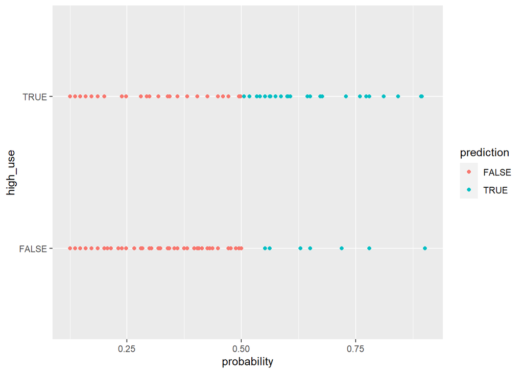

```r
# initialize a plot of 'high_use' versus 'probability' in 'alc'
g <- ggplot(alc, aes(x = probability, y = high_use,col = prediction))

# define the geom as points and draw the plot
g + geom_point()
```

```r
# propabilistic table ofte the target variable versus the predictions

table(high_use = alc$high_use, prediction = alc$prediction) %>% prop.table() %>% addmargins()
```

```
##         prediction
## high_use      FALSE       TRUE        Sum
##    FALSE 0.68108108 0.01891892 0.70000000
##    TRUE  0.21081081 0.08918919 0.30000000
##    Sum   0.89189189 0.10810811 1.00000000
```

The point plot visualizes the actual and predicted values. From the probabilistic table we can see that the model predicted 21% of students not belonging to the high use group when they in fact do and little less than 2% belonging to the high use group when they in fact don’t. The training error of the model is then approximately 0,23.